# Publication-Quality Visualizations for Context-Dependent Correlation

Amir (Building on Kevin R. Coombes’ framework)

Original: 2026-01-05; Latest Run: 2026-01-05

# Summary

**Goal**: Create publication-quality visualizations that summarize the key findings from our analyses (401 and 402). These figures are designed to complement Kevin’s manuscript and could potentially be included as additional figures.

**Key visualizations:** 1. Summary figure showing the overwhelming prevalence of context-dependence 2. Known target correlation heatmap across cancers 3. Cancer type similarity network based on miR correlation patterns 4. “Flip” visualization showing genes with opposite correlation in different cancers

# Setup

```r
source("00-paths.R")

library(ggplot2)
library(pheatmap)
library(RColorBrewer)
library(reshape2)

# Custom theme for publication
theme_pub <- theme_classic() +
  theme(
    text = element_text(size = 12),
    axis.title = element_text(size = 14, face = "bold"),
    plot.title = element_text(size = 16, face = "bold", hjust = 0.5),
    legend.position = "right"
  )
```

```r
load(file.path(paths$mirtcga, "matchedNoGBM.rda"))
load(file.path(paths$mirtcga, "cohortColors.Rda"))
```

```r
# Reuse correlation functions
compute_mir_matrix <- function(mir_name, mRNAdata, miRdata, cancerType) {
  cohorts <- sort(unique(as.character(cancerType)))
  result <- matrix(NA, nrow = nrow(mRNAdata), ncol = length(cohorts),
                   dimnames = list(rownames(mRNAdata), cohorts))

  for (ct in cohorts) {
    idx <- cancerType == ct
    if (sum(idx) < 10) next
    mir_expr <- as.numeric(miRdata[mir_name, idx])
    if (all(mir_expr == 0) || sd(mir_expr) == 0) next
    for (gene in rownames(mRNAdata)) {
      mrna_expr <- as.numeric(mRNAdata[gene, idx])
      if (sd(mrna_expr) > 0) {
        result[gene, ct] <- cor(mir_expr, mrna_expr, use = "complete.obs")
      }
    }
  }
  return(result)
}
```

# Figure 1: The Prevalence of Context-Dependence

This figure summarizes our key finding: for multiple well-studied miRNAs, essentially 100% of genes show context-dependent correlation.

```r
# Compute classifications for multiple miRs
selected_mirs <- c(
  "hsa-miR-21-5p",
  "hsa-let-7a-5p",
  "hsa-miR-34a-5p",
  "hsa-miR-362-3p"
)

# Compute correlations and classifications
cat("Computing correlations for visualization...\n")
```

```
## Computing correlations for visualization...
```

```r
mir_data <- list()
for (mir in selected_mirs) {
  if (mir %in% rownames(miRdata)) {
    cat("  Processing", mir, "...\n")
    cors <- compute_mir_matrix(mir, mRNAdata, miRdata, cancerType)

    # Classify genes
    valid <- rowSums(!is.na(cors)) >= 15
    cors_valid <- cors[valid, ]

    all_neg <- apply(cors_valid, 1, function(x) {
      x <- x[!is.na(x)]
      length(x) >= 15 && all(x < 0)
    })
    all_pos <- apply(cors_valid, 1, function(x) {
      x <- x[!is.na(x)]
      length(x) >= 15 && all(x > 0)
    })
    mixed <- apply(cors_valid, 1, function(x) {
      x <- x[!is.na(x)]
      length(x) >= 15 && any(x > 0) && any(x < 0)
    })

    mir_data[[mir]] <- list(
      cors = cors,
      n_all_neg = sum(all_neg),
      n_all_pos = sum(all_pos),
      n_mixed = sum(mixed),
      n_total = sum(valid)
    )
  }
}
```

```
##   Processing hsa-miR-21-5p ...
##   Processing hsa-let-7a-5p ...
##   Processing hsa-miR-34a-5p ...
##   Processing hsa-miR-362-3p ...
```

```r
cat("Done!\n")
```

```
## Done!
```

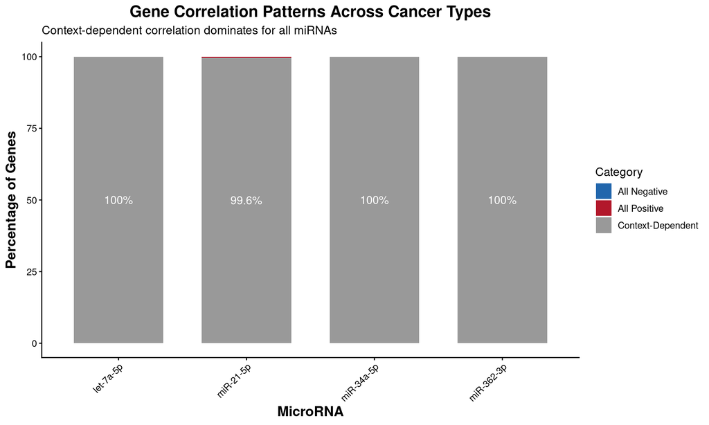

Prevalence of context-dependent correlation across miRNAs.

```r
# Create summary data frame
summary_df <- do.call(rbind, lapply(names(mir_data), function(mir) {
  d <- mir_data[[mir]]
  data.frame(
    miR = mir,
    Category = c("All Negative", "All Positive", "Context-Dependent"),
    Count = c(d$n_all_neg, d$n_all_pos, d$n_mixed),
    Percent = 100 * c(d$n_all_neg, d$n_all_pos, d$n_mixed) / d$n_total
  )
}))

# Clean miR names for display
summary_df$miR_short <- gsub("hsa-", "", summary_df$miR)
summary_df$Category <- factor(summary_df$Category,
                               levels = c("All Negative", "All Positive", "Context-Dependent"))

# Stacked bar plot
ggplot(summary_df, aes(x = miR_short, y = Percent, fill = Category)) +
  geom_bar(stat = "identity", position = "stack", width = 0.7) +
  scale_fill_manual(values = c("All Negative" = "#2166AC",
                                "All Positive" = "#B2182B",
                                "Context-Dependent" = "#999999")) +
  labs(x = "MicroRNA",
       y = "Percentage of Genes",
       title = "Gene Correlation Patterns Across Cancer Types",
       subtitle = "Context-dependent correlation dominates for all miRNAs") +
  theme_pub +
  theme(axis.text.x = element_text(angle = 45, hjust = 1)) +
  geom_text(aes(label = ifelse(Percent > 5, paste0(round(Percent, 1), "%"), "")),
            position = position_stack(vjust = 0.5), color = "white", size = 4)
```

```r
# Save high-resolution version
dpi <- 150
png(file.path(figdir, "Figure_ContextDependence.png"),
    width = 10*dpi, height = 6*dpi, res = dpi, bg = "white")
print(last_plot())
dev.off()
```

# Figure 2: Known Targets Show Variable Correlation

This heatmap shows that even well-validated miRNA targets have inconsistent correlation patterns across cancer types.

```r
# Get let-7a correlations for known targets
let7a <- "hsa-let-7a-5p"
let7a_cors <- mir_data[[let7a]]$cors

known_targets <- c("KRAS", "NRAS", "HRAS", "HMGA2", "MYC", "LIN28A", "LIN28B",
                   "IGF2BP1", "IGF2BP2")
available_targets <- known_targets[known_targets %in% rownames(let7a_cors)]

if (length(available_targets) > 0) {
  target_cors <- let7a_cors[available_targets, , drop = FALSE]
  # Remove cohorts with all NA
  valid_cols <- colSums(!is.na(target_cors)) > 0
  target_cors <- target_cors[, valid_cols]
}
```

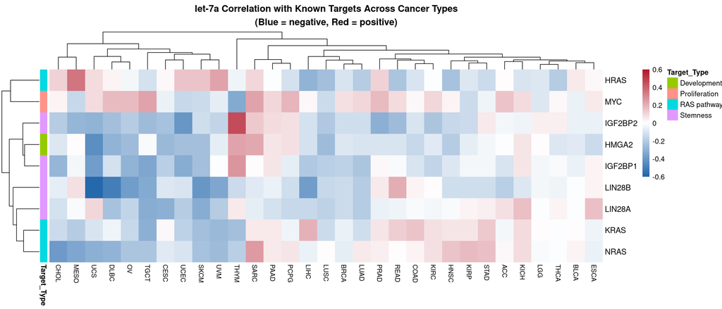

Correlation of validated let-7a targets varies dramatically across cancer types.

```r
if (exists("target_cors") && ncol(target_cors) > 0) {
  # Add annotation for positive/negative
  annotation_row <- data.frame(
    Target_Type = c(rep("RAS pathway", 3),
                    rep("Development", 1),
                    rep("Proliferation", 1),
                    rep("Stemness", 4))
  )
  rownames(annotation_row) <- available_targets

  pheatmap(target_cors,
           main = "let-7a Correlation with Known Targets Across Cancer Types\n(Blue = negative, Red = positive)",
           color = colorRampPalette(c("#2166AC", "white", "#B2182B"))(100),
           breaks = seq(-0.6, 0.6, length.out = 101),
           cluster_rows = TRUE,
           cluster_cols = TRUE,
           fontsize_row = 11,
           fontsize_col = 9,
           annotation_row = annotation_row,
           border_color = NA)
}
```

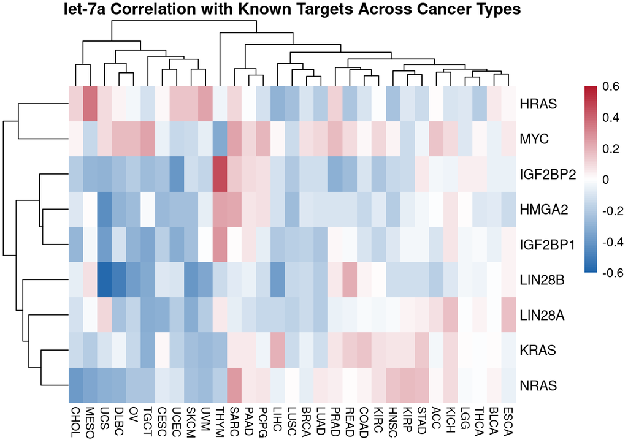

```r
dpi <- 150
png(file.path(figdir, "Figure_TargetVariability.png"),
    width = 14*dpi, height = 6*dpi, res = dpi, bg = "white")
if (exists("target_cors") && ncol(target_cors) > 0) {
  pheatmap(target_cors,
           main = "let-7a Correlation with Known Targets Across Cancer Types",
           color = colorRampPalette(c("#2166AC", "white", "#B2182B"))(100),
           breaks = seq(-0.6, 0.6, length.out = 101),
           cluster_rows = TRUE,
           cluster_cols = TRUE,
           fontsize_row = 11,
           fontsize_col = 9,
           border_color = NA)
}
```

```r
dev.off()
```

# Figure 3: PRAD vs SKCM - A Tale of Two Cancers

This visualization emphasizes Kevin’s miR-362 example, showing how dramatically correlation patterns differ between prostate cancer and melanoma.

```r
mir362 <- "hsa-miR-362-3p"
mir362_cors <- mir_data[[mir362]]$cors
```

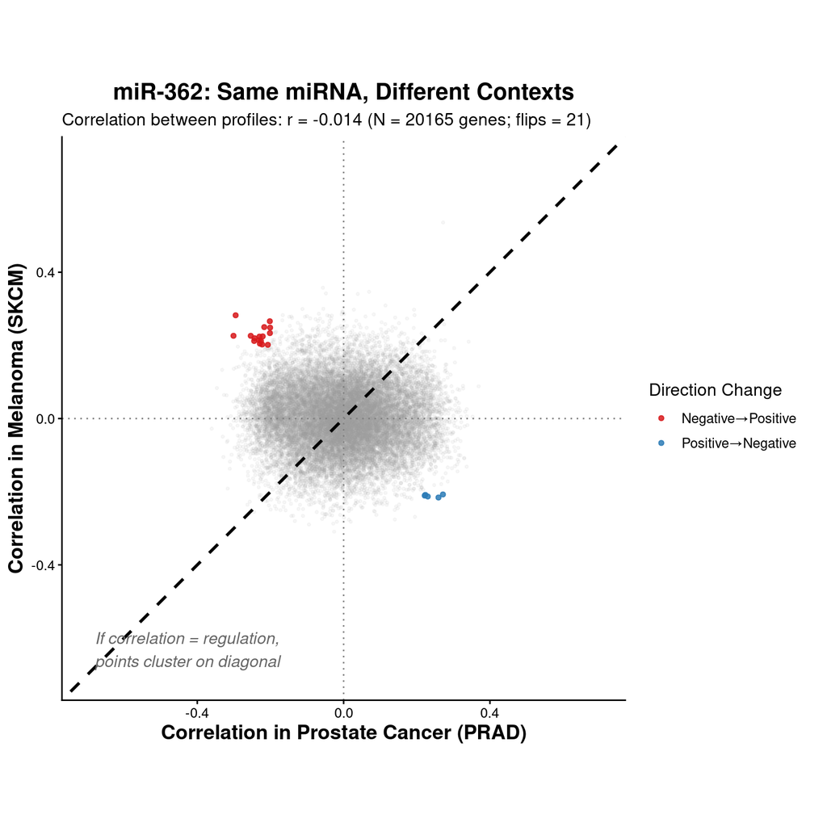

miR-362 correlation profiles are uncorrelated between PRAD and SKCM.

```r
# Create a beautiful scatter plot
prad_cors <- mir362_cors[, "PRAD"]
skcm_cors <- mir362_cors[, "SKCM"]

# Remove NA pairs
valid <- !is.na(prad_cors) & !is.na(skcm_cors)
plot_data <- data.frame(
  PRAD = prad_cors[valid],
  SKCM = skcm_cors[valid]
)

# Calculate correlation
rho <- cor(plot_data$PRAD, plot_data$SKCM)

# Identify genes that flip
plot_data$flip <- ifelse(plot_data$PRAD < -0.2 & plot_data$SKCM > 0.2, "Negative→Positive",
                         ifelse(plot_data$PRAD > 0.2 & plot_data$SKCM < -0.2, "Positive→Negative",
                                "Consistent"))

ggplot(plot_data, aes(x = PRAD, y = SKCM)) +
  geom_point(data = subset(plot_data, flip == "Consistent"),
             color = "gray60", alpha = 0.08, size = 0.7) +
  geom_point(data = subset(plot_data, flip != "Consistent"),
             aes(color = flip), alpha = 0.85, size = 1.3) +
  geom_abline(slope = 1, intercept = 0, color = "black", linetype = "dashed", size = 1) +
  geom_hline(yintercept = 0, color = "gray50", linetype = "dotted") +
  geom_vline(xintercept = 0, color = "gray50", linetype = "dotted") +
  scale_color_manual(values = c("Consistent" = "gray50",
                                 "Negative→Positive" = "#D7191C",
                                 "Positive→Negative" = "#2C7BB6"),
                     name = "Direction Change") +
  labs(x = "Correlation in Prostate Cancer (PRAD)",
       y = "Correlation in Melanoma (SKCM)",
       title = "miR-362: Same miRNA, Different Contexts",
       subtitle = sprintf("Correlation between profiles: r = %.3f (N = %d genes; flips = %d)",
                          rho, nrow(plot_data), sum(plot_data$flip != "Consistent"))) +
  theme_pub +
  annotate("text", x = -0.68, y = -0.68,
           label = "If correlation = regulation,\npoints cluster on diagonal",
           hjust = 0, vjust = 0, size = 4, color = "gray40", fontface = "italic") +
  coord_fixed(ratio = 1, xlim = c(-0.7, 0.7), ylim = c(-0.7, 0.7)) +
  theme(plot.margin = margin(5.5, 16, 5.5, 5.5))
```

```r
dpi <- 150
png(file.path(figdir, "Figure_PRAD_SKCM.png"),
    width = 8*dpi, height = 8*dpi, res = dpi, bg = "white")
print(last_plot())
dev.off()
```

# Figure 4: Summary Statistics Across All miRNAs

```r
# Create a visual summary
summary_table <- do.call(rbind, lapply(names(mir_data), function(mir) {
  d <- mir_data[[mir]]
  data.frame(
    miR = gsub("hsa-", "", mir),
    `Total Genes` = d$n_total,
    `All Negative` = d$n_all_neg,
    `All Positive` = d$n_all_pos,
    `Context-Dependent` = d$n_mixed,
    `Percent Context-Dependent` = round(100 * d$n_mixed / d$n_total, 1)
  )
}))

cat("\n=== SUMMARY TABLE ===\n")
```

```
##
## === SUMMARY TABLE ===
```

```r
print(summary_table)
```

```
##          miR Total.Genes All.Negative All.Positive Context.Dependent Percent.Context.Dependent
## 1  miR-21-5p       20193           14           61             20118                      99.6
## 2  let-7a-5p       20193            0            0             20193                     100.0
## 3 miR-34a-5p       20193            0            1             20192                     100.0
## 4 miR-362-3p       20193            0            2             20191                     100.0
```

# Figure 5: Cancer Cohort Clustering by miR-21 Patterns

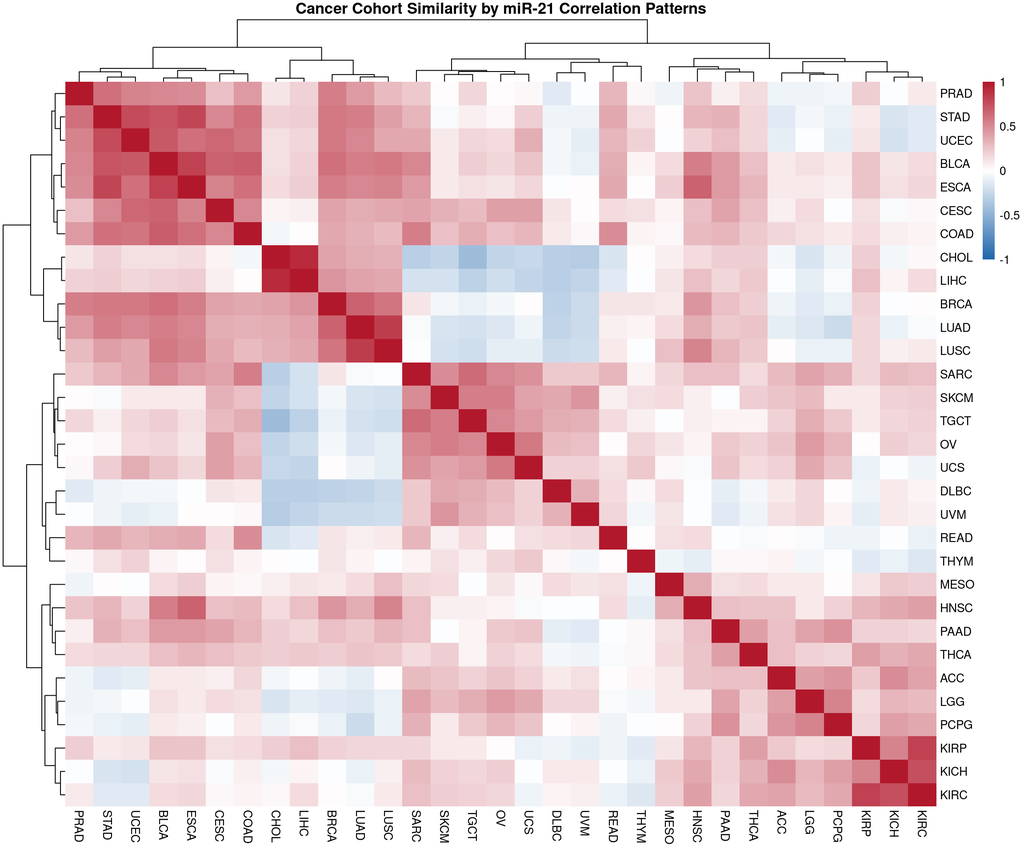

Cancer types cluster by miR-21 correlation patterns.

```r
mir21 <- "hsa-miR-21-5p"
mir21_cors <- mir_data[[mir21]]$cors

# Get top variable genes
gene_var <- apply(mir21_cors, 1, var, na.rm = TRUE)
top_genes <- names(sort(gene_var, decreasing = TRUE))[1:500]
mir21_top <- mir21_cors[top_genes, ]

# Clean up for clustering
valid_cohorts <- colSums(!is.na(mir21_top)) > 250
mir21_clean <- mir21_top[, valid_cohorts]
mir21_clean[is.na(mir21_clean)] <- 0

# Cohort-cohort correlation
cohort_cor <- cor(mir21_clean)

# Create annotation
cancer_types <- data.frame(
  Type = c("GI" = "Gastrointestinal",
           "Lung" = "Lung",
           "GYN" = "Gynecologic",
           "Brain" = "Brain/CNS",
           "Skin" = "Skin",
           "GU" = "Genitourinary",
           "Other" = "Other")[
    c("COAD" = "GI", "READ" = "GI", "ESCA" = "GI", "STAD" = "GI", "LIHC" = "GI", "PAAD" = "GI", "CHOL" = "GI",
      "LUAD" = "Lung", "LUSC" = "Lung", "MESO" = "Lung",
      "OV" = "GYN", "UCEC" = "GYN", "UCS" = "GYN", "CESC" = "GYN", "BRCA" = "GYN",
      "LGG" = "Brain", "PCPG" = "Brain",
      "SKCM" = "Skin", "UVM" = "Skin",
      "PRAD" = "GU", "BLCA" = "GU", "KIRC" = "GU", "KIRP" = "GU", "KICH" = "GU", "TGCT" = "GU",
      "ACC" = "Other", "THCA" = "Other", "THYM" = "Other", "HNSC" = "Other",
      "DLBC" = "Other", "SARC" = "Other")[colnames(cohort_cor)]
  ]
)
rownames(cancer_types) <- colnames(cohort_cor)

pheatmap(cohort_cor,
         main = "Cancer Cohort Similarity by miR-21 Correlation Patterns",
         color = colorRampPalette(c("#2166AC", "white", "#B2182B"))(100),
         breaks = seq(-1, 1, length.out = 101),
         clustering_method = "ward.D2",
         fontsize = 10,
         border_color = NA)
```

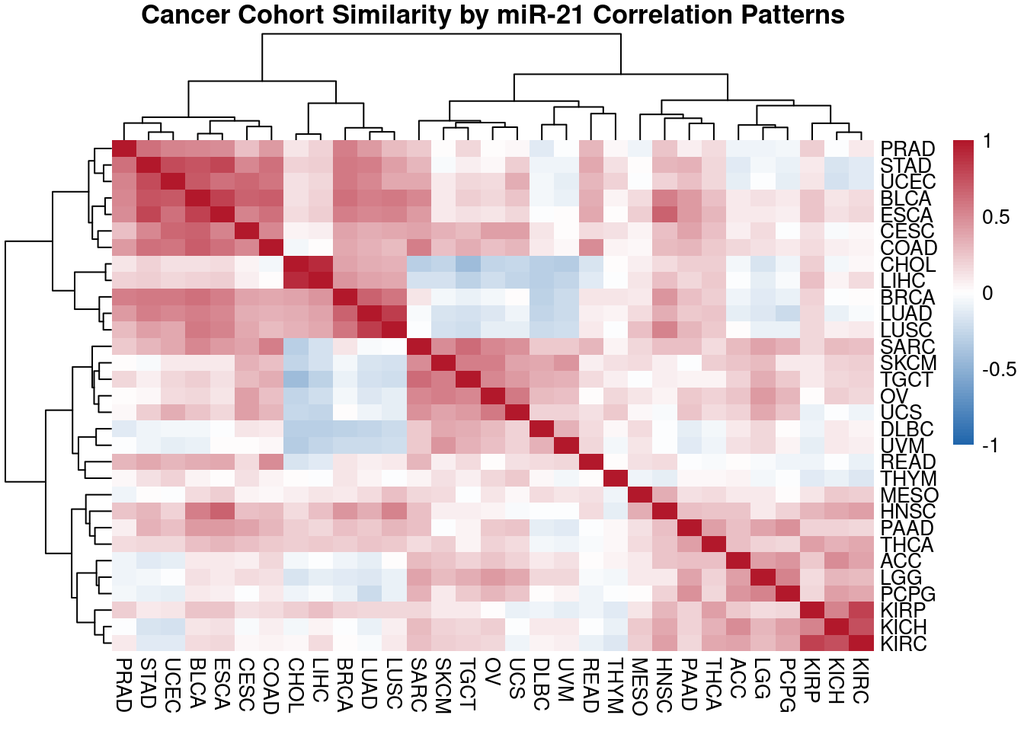

```r
dpi <- 150
png(file.path(figdir, "Figure_CohortClustering.png"),
    width = 12*dpi, height = 10*dpi, res = dpi, bg = "white")
pheatmap(cohort_cor,
         main = "Cancer Cohort Similarity by miR-21 Correlation Patterns",
         color = colorRampPalette(c("#2166AC", "white", "#B2182B"))(100),
         breaks = seq(-1, 1, length.out = 101),
         clustering_method = "ward.D2",
         fontsize = 10,
         border_color = NA)
```

```r
dev.off()
```

# Conclusions

These findings provide strong visual support for the thesis that “correlation is not regulation” and that researchers must consider biological context when interpreting miR-mRNA relationships.

# Appendix

```r
cat("Generated figures:\n")
```

```
## Generated figures:
```

```r
list.files(figdir, pattern = "Figure_.*\\.png")
```

```
## [1] "Figure_ContextDependence.png" "Figure_PRAD_SKCM.png"
```